# Język R jako narzędzie wizualizacji i raportowania - zajęcia 3

Marcin Koźniewski

# Zajęcia 3

### Wizualizacja i biblioteka ggplot2

- proste formy wizualizacji i przedstawiania danych
- ustawianie podstawowych cech wykresów
- źródła cech wykresu: stałe i zależne od danych
- podwykresy

## graphics

W R wizualizować można za pomocą prostych funkcji takich jak `hist`, `plot`, `lines`, `boxplot`, `pairs`. Stanowią one wbudowane narzędzia do wizualizacji. Biblioteka ggplot2 stanowi rozbudowane i uporządkowane narzędzie, które pozwala na schludną i przyjemną dla oka wizualizację. Istnieje wiele rozszerzeń, które sprawiają, że R z innymi bibliotekami do przetwarzania danych urasta do potężnego narzędzia do wizualizacji.

Wczytajmy znane nam już dane

```r
schorzenia_serca <- read.csv("heart_disease.csv")
head(schorzenia_serca)
```

|  | Gender | age | education | currentSmoker | cigsPerDay | BPMeds | prevalentStroke | prevalentHyp | diabetes | totChol | sysBP | diaBP | BMI | heartRate | glucose | Heart_.stroke |
| --- | --- | --- | --- | --- | --- | --- | --- | --- | --- | --- | --- | --- | --- | --- | --- | --- |
| 1 | Male | 39 | postgraduate | 0 | 0 | 0 | no | 0 | 0 | 195 | 106.0 | 70 | 26.97 | 80 | 77 | No |
| 2 | Female | 46 | primaryschool | 0 | 0 | 0 | no | 0 | 0 | 250 | 121.0 | 81 | 28.73 | 95 | 76 | No |
| 3 | Male | 48 | uneducated | 1 | 20 | 0 | no | 0 | 0 | 245 | 127.5 | 80 | 25.34 | 75 | 70 | No |
| 4 | Female | 61 | graduate | 1 | 30 | 0 | no | 1 | 0 | 225 | 150.0 | 95 | 28.58 | 65 | 103 | yes |
| 5 | Female | 46 | graduate | 1 | 23 | 0 | no | 0 | 0 | 285 | 130.0 | 84 | 23.10 | 85 | 85 | No |
| 6 | Female | 43 | primaryschool | 0 | 0 | 0 | no | 1 | 0 | 228 | 180.0 | 110 | 30.30 | 77 | 99 | No |

Kilka prostych wizualizacji dla wektorów danych, które podajemy jako argumenty

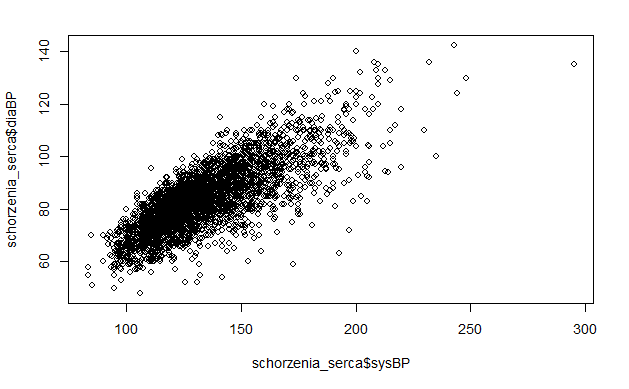

```r
#plot(x,y)
plot(schorzenia_serca$sysBP, schorzenia_serca$diaBP)
```

Kółeczka można zamienić na inne znaczki lub ustawić jako punkty lub nawet nadać im przeźroczystość. Zmienić tytuł, podpisy pod osiami itd.

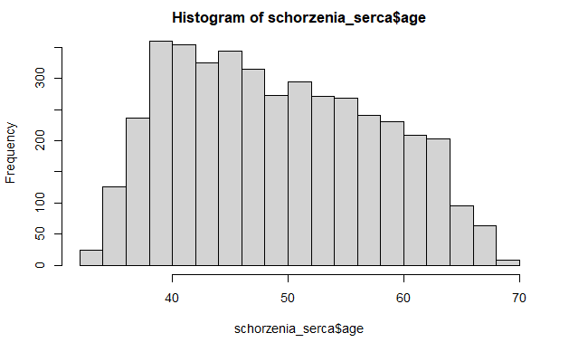

```r
#hist(x)
hist(schorzenia_serca$age)
```

O ile wykresy punktowe i histogramy rozumiemy do pewnego stopnia intuicyjnie. Aby zastąpić podstawowy zestaw statystyk opisowych wykresem, możemy wykorzystać wykres pudełkowy, który wymaga wyjaśnienia (obrazek CEZ).

Wykres pudełkowy przedstawia percentyle: 0-min, 25, 50-mediana, 75, 100-max.

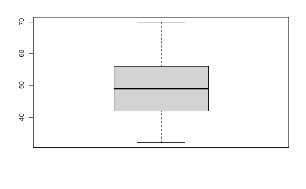

```r
boxplot(schorzenia_serca$age)
```

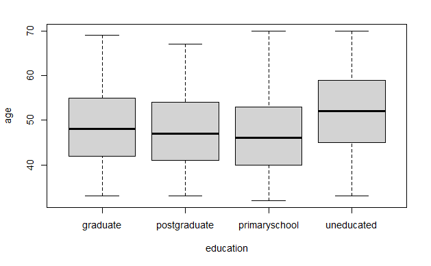

```r
#boxplot(CO ~ PODZIAŁ_GRUPY, data=NASZE_DANE)
boxplot(age ~ education, data=schorzenia_serca)
```

Szybki podgląd zależności w danych. (wybieram tylko część kolumn)

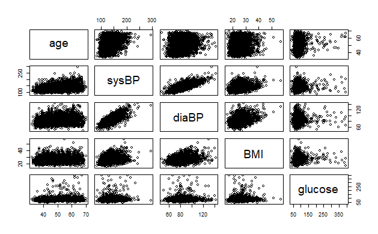

```r
pairs(schorzenia_serca[,c("age","sysBP","diaBP","BMI", "glucose")] )
```

## ggplot2

```r
library(ggplot2) #może wymagać instalacji
```

Zacznijmy od najprostszego wykresu

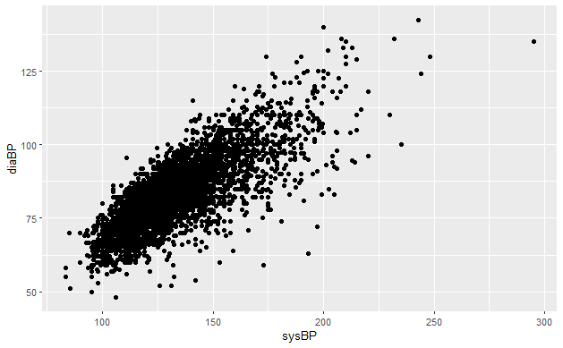

```r
#ggplot(RAMKA_DANYCH) +
#  geom_*(aes(x,y))

ggplot(schorzenia_serca) +
  geom_point(aes(sysBP, diaBP))
```

Najpierw wskazujemy zbiór danych przekazywany do ggplot. Następnie nadajemy geometrię (w tym wypadku dane wyświetlamy jako punkty) wskazując, co mają reprezentować współrzędne - dane z których kolumn mają być zobrazowane. Proszę zwrócić uwagę, że piszemy nazwy kolumn bez cudzysłowów.

Widzimy, że domyślnie wykres jest schludny i nie wygląda ubogo. Widzimy dokładne osie opisane nazwami kolumn z których pochodzą dane. Tło wykresu stanowi delikatne szare pole z zarysowanymi prowadnicami na podziałkach osi. Wszystkie te elementy w łatwy sposób będzie można zmodyfikować “dodając” modyfikatory wykresu lub różne elementy.

Zmodyfikujmy kolor wykresu. Do tego można stosować kodów szesnastkowych RGB lub prościej - predefiniowanych kolorów, które możemy poznać z użyciem funkcji `colors()`.

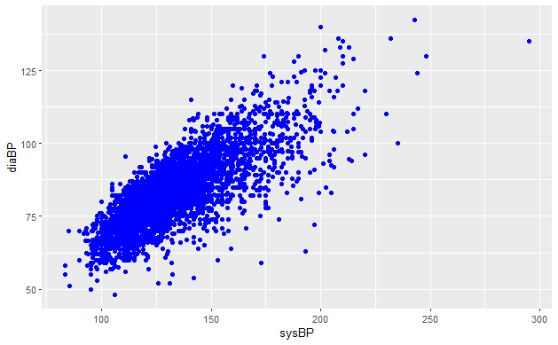

```r
#dodaliśmy parametr color do geom_point
ggplot(schorzenia_serca) +
  geom_point(aes(sysBP, diaBP), color="blue")
```

Punktów jest bardzo dużo, więc możemy chcieć przytłumić intensywność koloru przez dodanie do każdego punktu przeźroczystości. Wyrysowanie punktu w tym samym miejscu spowoduje intensyfikację koloru.

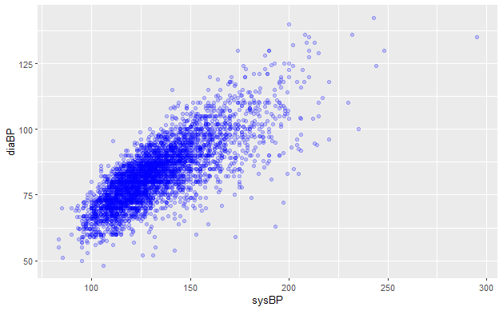

```r
#dodaliśmy parametr alpha do geom_point
ggplot(schorzenia_serca) +
  geom_point(aes(sysBP, diaBP), color="blue", alpha=0.2)
```

Możemy też modyfikować inne parametry wyświetlanych punktów jak ich rozmiar.

```r
#dodaliśmy parametr size do geom_point
ggplot(schorzenia_serca) +
  geom_point(aes(sysBP, diaBP), color="blue", alpha=0.2, size=1)
```

Zmodyfikujmy kolejne elementy wykresu: dodajmy tytuł. Jak to zrobić? Trzeba dodać funkcję `ggtitle()`.

```r
#dodaliśmy element ggtitle
ggplot(schorzenia_serca) +
  geom_point(aes(sysBP, diaBP), color="blue", alpha=0.2, size=1) +
  ggtitle("Blood pressure")
```

Chcemy zmienić etykiety osi? Proszę bardzo. `xlab()` i `ylab()`

```r
#dodaliśmy elementy xlab i ylab
ggplot(schorzenia_serca) +
  geom_point(aes(sysBP, diaBP), color="blue", alpha=0.2, size=1) +
  ggtitle("Blood pressure") +
  xlab("Systolic (mm Hg)") +
  ylab("Diastolic (mm Hg)")
```

Niektórzy nie lubią tego szarego tła. Zmieńmy zatem tło wykresu ustawiając odpowiedni theme, np. `theme_bw()`

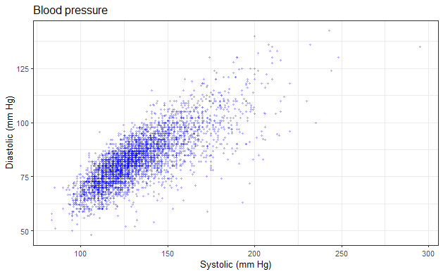

```r
#dodaliśmy elementy xlab i ylab
ggplot(schorzenia_serca) +
  geom_point(aes(sysBP, diaBP), color="blue", alpha=0.2, size=1) +
  ggtitle("Blood pressure") +
  xlab("Systolic (mm Hg)") +
  ylab("Diastolic (mm Hg)") +
  theme_bw()
```

Dlaczego arytmetyka wykresu jest użyteczna? Można zapisać wykres pod zmienną następnie go uzupełniać tworząc różne warianty tego samego wykresu. Programiści lubią takie możliwości “dekorowania” wykresu. Te same dane możemy w różny sposób wyrysowywać ale też możemy przekształcać samą geometrię lub dodawać kolejne wyświetlane elementy.

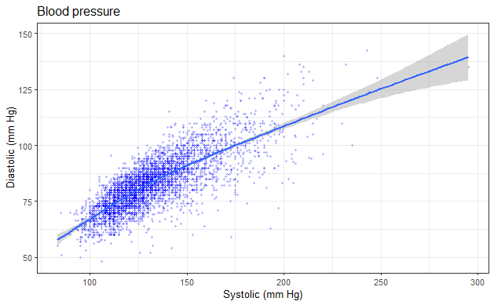

```r
#dodaliśmy elementy xlab i ylab
ggplot(schorzenia_serca) +
  geom_point(aes(sysBP, diaBP), color="blue", alpha=0.2, size=1) +
  ggtitle("Blood pressure") +
  xlab("Systolic (mm Hg)") +
  ylab("Diastolic (mm Hg)") +
  theme_bw() +
  geom_smooth(aes(sysBP, diaBP)) # dodaliśmy linię aproksymacji (wygładzającą)
```

Takich elementów geometrii możemy dodawać więcej.

Chcemy jednak aby nasze wykresy prezentowały więcej informacji niż tylko dwie kolumny. W poszukiwaniu zależności związanych z wartościami dyskretnymi chcemy rozróżniać różne klasy obiektów na wykresie np. przez zakolorowanie ich w inny sposób.

Do tego celu stosujemy dodajemy to co ma być zależne w prezentacji danych do parametru `mapping` - mapowania tworzonego za pomocą funkcji `aes()`

Sprawdźmy osoby, które miały atak serca

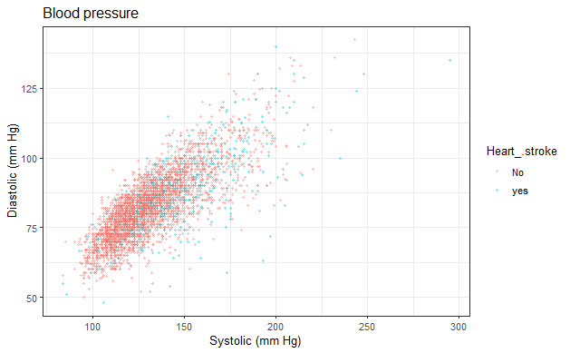

```r
ggplot(schorzenia_serca) +
  geom_point(aes(x=sysBP, y=diaBP, color=Heart_.stroke),alpha=0.3, size=1) + #w tej linii!
  ggtitle("Blood pressure") +
  xlab("Systolic (mm Hg)") +
  ylab("Diastolic (mm Hg)") +
  theme_bw()
```

PROSZĘ ZWRÓCIĆ UWAGĘ NA BRAK PARAMETRU `color` NA ZEWNĄTRZ `aes` !!!

Kilka przykładów.

```r
ggplot(schorzenia_serca) +
  geom_point(aes(x=sysBP, y=diaBP, color=Gender),alpha=0.3, size=1) + #w tej linii!
  ggtitle("Blood pressure") +
  xlab("Systolic (mm Hg)") +
  ylab("Diastolic (mm Hg)") +
  theme_bw()
```

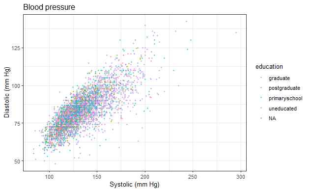

```r
ggplot(schorzenia_serca) +
  geom_point(aes(x=sysBP, y=diaBP, color=education),alpha=0.5, size=1) + #w tej linii!
  ggtitle("Blood pressure") +
  xlab("Systolic (mm Hg)") +
  ylab("Diastolic (mm Hg)") +
  theme_bw()
```

(Eh tutaj nic nie widać…)

To samo możemy zrobić z rozmiarem punktów (im większa kropka tym większa wartość w zadanej kolumnie), ich przeźroczystością (alpha).

## Inne wykresy niż punktowe

```r
ggplot(schorzenia_serca) +
  geom_histogram(aes(x=age)) +
  theme_bw()
```

```r
ggplot(schorzenia_serca) +
  geom_histogram(aes(x=age, color=Gender)) +
  theme_bw()
```

```r
ggplot(schorzenia_serca) +
  geom_histogram(aes(x=age, fill=Gender)) +
  theme_bw()
```

```r
ggplot(schorzenia_serca) +
  geom_histogram(aes(x=age, fill=Gender), position="dodge") + #pozycja obok siebie
  theme_bw()
```

Te kolory mogą być trudne w odbiorze. Do zmiany kolorystyki poszczególnych grup wykorzystujemy rodzinę funkcji scale_

```r
ggplot(schorzenia_serca) +
  geom_histogram(aes(x=age, fill=Gender), position="dodge") +
  theme_bw() +
  scale_fill_manual(values=c("darkgreen","darkblue"))
```

Dla niektórych rozróżnianie tylko dwóch klas to może być za mało. Zatem podzielmy wykres na podwykresy gdzie będziemy mieli różne podgrupy.

```r
ggplot(schorzenia_serca) +
  geom_histogram(aes(x=age, fill=Gender), position="dodge") +
  theme_bw() +
  scale_fill_manual(values=c("darkgreen","darkblue")) +
  facet_grid(~education)
```

```r
ggplot(schorzenia_serca) +
  geom_histogram(aes(x=age, fill=Gender), position="dodge") +
  theme_bw() +
  scale_fill_manual(values=c("darkgreen","darkblue")) +
  facet_grid(education~.) #potrzebna jest kropka
```

```r
ggplot(schorzenia_serca) +
  geom_histogram(aes(x=age, fill=Gender), position="dodge") +
  theme_bw() +
  scale_fill_manual(values=c("darkgreen","darkblue")) +
  facet_grid(education~.) #potrzebna jest kropka
```

# dplyr + ggplot2

demo na żywo :-)

# Zadanie

Wykorzystać dowolny inny zbiór danych i utworzyć wykres z dostosowanymi ustawieniami.

```r
example_data <- read.csv("kalimati_tarkari_dataset.csv")
head(example_data)
```

|  | SN | Commodity | Date | Unit | Minimum | Maximum | Average |
| --- | --- | --- | --- | --- | --- | --- | --- |
| 1 | 0 | Tomato Big(Nepali) | 2013-06-16 | Kg | 35 | 40 | 37.5 |
| 2 | 1 | Tomato Small(Local) | 2013-06-16 | Kg | 26 | 32 | 29.0 |
| 3 | 2 | Potato Red | 2013-06-16 | Kg | 20 | 21 | 20.5 |
| 4 | 3 | Potato White | 2013-06-16 | Kg | 15 | 16 | 15.5 |
| 5 | 4 | Onion Dry (Indian) | 2013-06-16 | Kg | 28 | 30 | 29.0 |
| 6 | 5 | Carrot(Local) | 2013-06-16 | Kg | 30 | 35 | 32.5 |

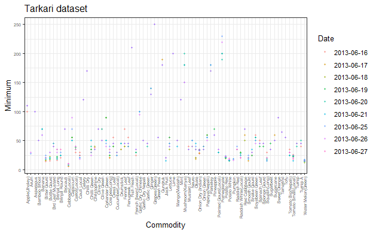

```r
ggplot(example_data[0:600,]) +
  geom_point(aes(Commodity, Minimum, color=Date), alpha=0.5, size=1) +
  ggtitle('Tarkari dataset') +
  xlab('Commodity') +
  ylab('Minimum') +
  theme_bw() +
  theme(axis.text=element_text(size=6)) +
  scale_x_discrete(guide = guide_axis(angle = 90))
```